# Known map experiment - feature extraction time

We are analyzing if offloading any of the three functionalities (i.e., localisation, navigation and object recognition) has a statistically significant effect on the average feature extraction time. Fist, install and load the required libraries:

```r
if (!require('tidyverse')) install.packages('tidyverse', dependencies = TRUE); library('tidyverse')
if (!require('ggpubr')) install.packages('ggpubr', dependencies = TRUE); library('ggpubr')
if (!require('rstatix')) install.packages('rstatix', dependencies = TRUE); library('rstatix')
if (!require('ggplot2')) install.packages('ggplot2', dependencies = TRUE); library('ggplot2')
if (!require('lmPerm')) install.packages('lmPerm', dependencies = TRUE); library('lmPerm')
if (!require('emmeans')) install.packages('emmeans', dependencies = TRUE); library('emmeans')
```

Next, load the experiment results from the csv file:

```r
data <- read.csv(file = '../../raw_data/known_map_experiment/run_table.csv')
data <- subset(data, select = c(X__run_id, amcl_offloaded, navigation_offloaded, obj_recognition_offloaded, avg_extraction_time_ms))
data$amcl_offloaded <- as.factor(data$amcl_offloaded)
data$navigation_offloaded <- as.factor(data$navigation_offloaded)
data$obj_recognition_offloaded <- as.factor(data$obj_recognition_offloaded)
data$avg_extraction_time_ms <- as.numeric(data$avg_extraction_time_ms)
```

Mean and standard deviation of the average feature extraction time for each treatment are displayed in the summary below:

```r
data %>%
  group_by(amcl_offloaded, navigation_offloaded, obj_recognition_offloaded) %>%
  get_summary_stats(avg_extraction_time_ms, type = "mean_sd")
```

| amcl_offloaded | navigation_offloaded | obj_recognition_offloaded | variable | n | mean | sd |
| --- | --- | --- | --- | --- | --- | --- |
| false | false | false | avg_extraction_time_ms | 10 | 36.427 | 0.245 |
| false | false | true | avg_extraction_time_ms | 10 | 5.939 | 0.325 |
| false | true | false | avg_extraction_time_ms | 10 | 36.093 | 0.211 |
| false | true | true | avg_extraction_time_ms | 10 | 5.641 | 0.354 |
| true | false | false | avg_extraction_time_ms | 10 | 36.197 | 0.193 |
| true | false | true | avg_extraction_time_ms | 10 | 5.649 | 0.496 |
| true | true | false | avg_extraction_time_ms | 10 | 36.215 | 0.381 |
| true | true | true | avg_extraction_time_ms | 10 | 5.934 | 0.443 |

# Three-Way ANOVA test

Since there are three independent variables in the experiment, we opt for three-way ANOVA test. First, we need to check if all assumptions for performing the test are met. The fist assumption of having independent observations is met inherently according to the way the experiment itself is conducted.

## No extreme outliers assumption

Next, we need to check if there are any extreme outliers:

```r
data %>%
  group_by(amcl_offloaded, navigation_offloaded, obj_recognition_offloaded) %>%
  identify_outliers(avg_extraction_time_ms)
```

| amcl_offloaded | navigation_offloaded | obj_recognition_offloaded | X__run_id | avg_extraction_time_ms | is.outlier | is.extreme |
| --- | --- | --- | --- | --- | --- | --- |
| false | false | true | run_22 | 5.107502 | TRUE | TRUE |
| false | false | true | run_76 | 6.319970 | TRUE | FALSE |
| true | true | true | run_9 | 5.335404 | TRUE | FALSE |
| true | true | true | run_13 | 4.967449 | TRUE | TRUE |

The results show that there are four outliers, in runs 22, 76, 9 and 13, respectfully, while runs 22 and 13 represent extreme outliers. We should remove the said runs from the dataset, but we can also leave them if we believe that they will not have a significant effect on the obtained results. Let us make an alternative dataset with the extreme outliers being removed:

```r
data_without_outliers <- data
data_without_outliers <- data_without_outliers[!(data_without_outliers$X__run_id == 'run_22'),]
data_without_outliers <- data_without_outliers[!(data_without_outliers$X__run_id == 'run_13'),]
```

We proceed to check the next assumption - normality of the data.

## Normality assumption by analyzing the model residuals

The first way to check normality assumption is by analyzing the model residuals:

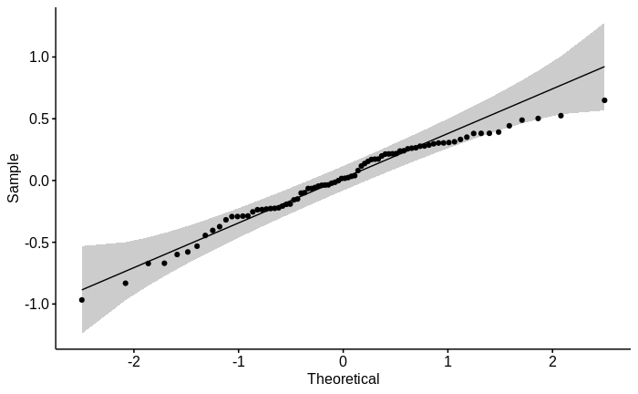

```r
model  <- lm(avg_extraction_time_ms ~ amcl_offloaded*navigation_offloaded*obj_recognition_offloaded, data = data)
ggqqplot(residuals(model))
```

The QQ plot in the figure above shows that most of the residuals are aligned with the reference line, thus we can assume that the residuals are normally distributed. We will complement the QQ plot with Shapiro-Wilk test to conclude if the normality is indeed satisfied:

```r
shapiro_test(residuals(model)) %>%
  add_significance()
```

| variable | statistic | p.value | p.value.signif |
| --- | --- | --- | --- |
| residuals(model) | 0.9678769 | 0.04159374 | * |

The p-value of `0.042` shows that we can reject $H_0$, which states that the data is indeed normally distributed. We can conclude that the normally constraint is not satisfied. If we try with the dataset that does not contain outliers:

```r
model_without_outliers  <- lm(avg_extraction_time_ms ~ amcl_offloaded*navigation_offloaded*obj_recognition_offloaded, data = data_without_outliers)
shapiro_test(residuals(model_without_outliers)) %>%
  add_significance()
```

| variable | statistic | p.value | p.value.signif |
| --- | --- | --- | --- |
| residuals(model_without_outliers) | 0.9795262 | 0.2422519 | ns |

we can now conclude that that normality of residuals is satisfied since p-value is higher than 0.05.

## Normality assumption by each group

The other way to check normality is by analyzing if samples for each possible treatment combination are normally distributed:

```r
data %>%
  group_by(amcl_offloaded, navigation_offloaded, obj_recognition_offloaded) %>%
  shapiro_test(avg_extraction_time_ms) %>%
  add_significance()
```

| amcl_offloaded | navigation_offloaded | obj_recognition_offloaded | variable | statistic | p | p.signif |
| --- | --- | --- | --- | --- | --- | --- |
| false | false | false | avg_extraction_time_ms | 0.8881107 | 0.16145202 | ns |
| false | false | true | avg_extraction_time_ms | 0.7618319 | 0.00497314 | ** |
| false | true | false | avg_extraction_time_ms | 0.8352987 | 0.03875025 | * |
| false | true | true | avg_extraction_time_ms | 0.8191684 | 0.02476196 | * |
| true | false | false | avg_extraction_time_ms | 0.9694787 | 0.88597017 | ns |
| true | false | true | avg_extraction_time_ms | 0.8285528 | 0.03214405 | * |
| true | true | false | avg_extraction_time_ms | 0.9059082 | 0.25405027 | ns |
| true | true | true | avg_extraction_time_ms | 0.8138651 | 0.02135917 | * |

Shapiro-Wilk test per each group yields p-value higher than `0.05` for only three groups. If we execute the test on the dataset without extreme outliers:

```r
data_without_outliers %>%
  group_by(amcl_offloaded, navigation_offloaded, obj_recognition_offloaded) %>%
  shapiro_test(avg_extraction_time_ms) %>%
  add_significance()
```

| amcl_offloaded | navigation_offloaded | obj_recognition_offloaded | variable | statistic | p | p.signif |
| --- | --- | --- | --- | --- | --- | --- |
| false | false | false | avg_extraction_time_ms | 0.8881107 | 0.16145202 | ns |
| false | false | true | avg_extraction_time_ms | 0.8357795 | 0.05182628 | ns |
| false | true | false | avg_extraction_time_ms | 0.8352987 | 0.03875025 | * |
| false | true | true | avg_extraction_time_ms | 0.8191684 | 0.02476196 | * |
| true | false | false | avg_extraction_time_ms | 0.9694787 | 0.88597017 | ns |
| true | false | true | avg_extraction_time_ms | 0.8285528 | 0.03214405 | * |
| true | true | false | avg_extraction_time_ms | 0.9059082 | 0.25405027 | ns |
| true | true | true | avg_extraction_time_ms | 0.8391311 | 0.05648283 | ns |

we still have three groups with significant p-values that are lower than `0.05` thus indicating non-normal distribution. The QQ-plots per group are depicted below, where the data seems to be aligned with the respective reference lines for most of the groups:

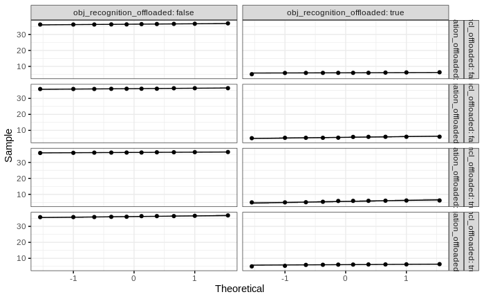

```r
ggqqplot(data, "avg_extraction_time_ms", ggtheme = theme_bw()) +
  facet_grid(amcl_offloaded + navigation_offloaded ~ obj_recognition_offloaded, labeller = "label_both")
```

## Homogeneity of variance assumption

Homogeneity of variance assumption can be checked via Levene’s test:

```r
data %>%
  levene_test(avg_extraction_time_ms ~ amcl_offloaded*navigation_offloaded*obj_recognition_offloaded) %>%
  add_significance()
```

| df1 | df2 | statistic | p | p.signif |
| --- | --- | --- | --- | --- |
| 7 | 72 | 1.681675 | 0.1271501 | ns |

Since the p-value is higher than `0.05`, the result of the Levene’s test is not statistically significant, hence the assumption for homogeneity of variance holds. If we try the same test on data frame without outliers:

```r
data_without_outliers %>%
  levene_test(avg_extraction_time_ms ~ amcl_offloaded*navigation_offloaded*obj_recognition_offloaded) %>%
  add_significance()
```

| df1 | df2 | statistic | p | p.signif |
| --- | --- | --- | --- | --- |
| 7 | 70 | 3.024246 | 0.007774386 | ** |

we get quite some different result leading to the conclusion that homogeneity of variance does not hold. Since homogeneity of variance assumption is more important for performing ANOVA then normality, yet since normality of the data is not satisfied and there are outliers, we will perform non-parametric alternative to three-way ANOVA, permutation test, and complement its results with three-way ANOVA.

# Permutation test

Execution of permutation test yields the following result:

```r
summary(aovp(avg_extraction_time_ms ~ amcl_offloaded*navigation_offloaded*obj_recognition_offloaded, data = data, perm="Prob", maxIter=500000, nCycle=100, Ca=0.001))
```

```
[1] "Settings:  unique SS "
Component 1 :
                                                              Df R Sum Sq R Mean Sq   Iter  Pr(Prob)
amcl_offloaded                                                 1      0.0       0.0 218028  0.821000
navigation_offloaded                                           1      0.1       0.1 500000  0.261726
amcl_offloaded:navigation_offloaded                            1      1.1       1.1 500000  0.003288 **
obj_recognition_offloaded                                      1  18534.6   18534.6 500000 < 2.2e-16 ***
amcl_offloaded:obj_recognition_offloaded                       1      0.0       0.0 212672  0.824627
navigation_offloaded:obj_recognition_offloaded                 1      0.1       0.1 500000  0.268370
amcl_offloaded:navigation_offloaded:obj_recognition_offloaded  1      0.1       0.1 500000  0.509522
Residuals                                                     72      8.6       0.1
---
Signif. codes:  0 ‘***’ 0.001 ‘**’ 0.01 ‘*’ 0.05 ‘.’ 0.1 ‘ ’ 1
```

Test results show that the main effect is significant only when object recognition is offloaded, but there is a significant two-way interaction between localisation and navigation. If we compare these results with three-way ANOVA results, that is considered as *robust* when sample sizes are equal for each group, which is indeed the case in this experiment:

```r
data %>%
  anova_test(avg_extraction_time_ms ~ amcl_offloaded*navigation_offloaded*obj_recognition_offloaded)
```

```
Coefficient covariances computed by hccm()
```

```
ANOVA Table (type II tests)

                                                         Effect DFn DFd          F         p p<.05   ges
1                                                amcl_offloaded   1  72      0.117  7.34e-01       0.002
2                                          navigation_offloaded   1  72      1.122  2.93e-01       0.015
3                                     obj_recognition_offloaded   1  72 154501.380 1.06e-121     * 1.000
4                           amcl_offloaded:navigation_offloaded   1  72      9.136  3.00e-03     * 0.113
5                      amcl_offloaded:obj_recognition_offloaded   1  72      0.131  7.18e-01       0.002
6                navigation_offloaded:obj_recognition_offloaded   1  72      0.953  3.32e-01       0.013
7 amcl_offloaded:navigation_offloaded:obj_recognition_offloaded   1  72      0.562  4.56e-01       0.008
```

we see that the obtained p-values and conclusions are very similar to those drawn from the permutation test. The eta-squared effect sizes are:

```r
res.aov <- aov(avg_extraction_time_ms ~ amcl_offloaded*navigation_offloaded*obj_recognition_offloaded, data = data)
eta_squared(res.aov)
```

```
                                               amcl_offloaded                                          navigation_offloaded
                                                 7.547043e-07                                                  7.258858e-06
                                    obj_recognition_offloaded                           amcl_offloaded:navigation_offloaded
                                                 9.994565e-01                                                  5.909928e-05
                     amcl_offloaded:obj_recognition_offloaded                navigation_offloaded:obj_recognition_offloaded
                                                 8.497903e-07                                                  6.163558e-06
amcl_offloaded:navigation_offloaded:obj_recognition_offloaded
                                                 3.632418e-06
```

## Pairwise comparisons for significant amcl_offloaded:navigation_offloaded two-way interaction

Since we have a significant two-way interaction between localisation and navigation, we need to perform multiple pairwise comparison to determine which group means are different. We will use estimated marginal means test for this purpose with Bonferroni adjustment. We will group the result by localisation variable:

```r
data %>%
  group_by(amcl_offloaded) %>%
  emmeans_test(avg_extraction_time_ms ~ navigation_offloaded, p.adjust.method = "bonferroni", detailed = TRUE)
```

|  | amcl_offloaded | term | .y. | group1 | group2 | null.value | estimate | se | df | conf.low | conf.high | statistic | p | p.adj | p.adj.signif |
| --- | --- | --- | --- | --- | --- | --- | --- | --- | --- | --- | --- | --- | --- | --- | --- |
| 1 | false | navigation_offloaded | avg_extraction_time_ms | false | true | 0 | 0.3161325 | 4.939565 | 76 | -9.521865 | 10.154130 | 0.06400006 | 0.9491382 | 0.9491382 | ns |
| 2 | true | navigation_offloaded | avg_extraction_time_ms | false | true | 0 | -0.1520511 | 4.939565 | 76 | -9.990048 | 9.685946 | -0.03078229 | 0.9755239 | 0.9755239 | ns |

However, the results for neither of the groups seem significant. If we try to apply the same test, but grouped by navigation instead:

```r
data %>%
  group_by(navigation_offloaded) %>%
  emmeans_test(avg_extraction_time_ms ~ amcl_offloaded, p.adjust.method = "bonferroni", detailed = TRUE)
```

|  | navigation_offloaded | term | .y. | group1 | group2 | null.value | estimate | se | df | conf.low | conf.high | statistic | p | p.adj | p.adj.signif |
| --- | --- | --- | --- | --- | --- | --- | --- | --- | --- | --- | --- | --- | --- | --- | --- |
| 1 | false | amcl_offloaded | avg_extraction_time_ms | false | true | 0 | 0.2605453 | 4.939565 | 76 | -9.577452 | 10.098542 | 0.05274661 | 0.9580722 | 0.9580722 | ns |
| 2 | true | amcl_offloaded | avg_extraction_time_ms | false | true | 0 | -0.2076383 | 4.939565 | 76 | -10.045635 | 9.630359 | -0.04203574 | 0.9665804 | 0.9665804 | ns |

# Results

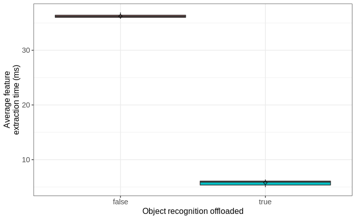

```r
#pdf(file = "../../figures/known_map_experiment/extraction-time-1.pdf")

ggplot(data, aes(x = obj_recognition_offloaded, y = avg_extraction_time_ms, fill = obj_recognition_offloaded)) +
  theme_bw() +
  geom_boxplot(width = 0.9, outlier.size = 0.5) +
  stat_summary(fun = mean, color = 'black', geom = 'point', shape = 5) +
  labs(x = "Object recognition offloaded", y = "Average feature\nextraction time (ms)") +
  theme(legend.position = "none") +
  theme(
    axis.title.x = element_text(size = 12, family = 'sans'),
    axis.title.y = element_text(size = 12, family = 'sans'),
    axis.text.x = element_text(size = 11, family = 'sans'),
    axis.text.y = element_text(size = 11, family = 'sans')
  )
```

```r
#dev.off()
```

We can indeed see from the boxplot above that the feature extraction time is much lower when object recognition is offloaded.